# [ 시각화 - Matplotlib, Seaborn ]

- [T-Academy X KaKr] 성인 인구조사 소득 예측 대회
- dataset : https://www.kaggle.com/c/kakr-4th-competition/

### [ Matplotlib ]

- 그래프 출력 : plot(), subplot()
- 히스토그램 : hist()
- 파이 그래프 : pie()

### [ Seaborn ]

- 막대그래프 : countplot(), barplot()
- 상자그림 : boxplot()
- 회귀분석(회귀직선 & 산점도) : lmplot()
- 산점도 : scatterplot()
- 선 그래프 : lineplot()
- 히트맵 : heatmap() - dataset.pivot()
- 히스토그램 : distplot()

### 데이터 불러오기

```python
import pandas as pd

print(pd.__version__)
```

```
1.0.5
```

```python
train = pd.read_csv("Income_train.csv")
test = pd.read_csv("Income_test.csv")
sub = pd.read_csv("Income_sample_submission.csv")
```

### 데이터 확인

```python
train.shape, test.shape, sub.shape
```

```
((26049, 16), (6512, 15), (6512, 2))
```

```python
train.columns, test.columns, sub.columns
```

```
(Index(['id', 'age', 'workclass', 'fnlwgt', 'education', 'education_num',
        'marital_status', 'occupation', 'relationship', 'race', 'sex',
        'capital_gain', 'capital_loss', 'hours_per_week', 'native_country',
        'income'],
       dtype='object'),
 Index(['id', 'age', 'workclass', 'fnlwgt', 'education', 'education_num',
        'marital_status', 'occupation', 'relationship', 'race', 'sex',
        'capital_gain', 'capital_loss', 'hours_per_week', 'native_country'],
       dtype='object'),
 Index(['id', 'prediction'], dtype='object'))
```

```python
print(train.info(), "\n")
print(test.info())
```

```
<class 'pandas.core.frame.DataFrame'>
RangeIndex: 26049 entries, 0 to 26048
Data columns (total 16 columns):
 #   Column          Non-Null Count  Dtype
---  ------          --------------  -----
 0   id              26049 non-null  int64
 1   age             26049 non-null  int64
 2   workclass       26049 non-null  object
 3   fnlwgt          26049 non-null  int64
 4   education       26049 non-null  object
 5   education_num   26049 non-null  int64
 6   marital_status  26049 non-null  object
 7   occupation      26049 non-null  object
 8   relationship    26049 non-null  object
 9   race            26049 non-null  object
 10  sex             26049 non-null  object
 11  capital_gain    26049 non-null  int64
 12  capital_loss    26049 non-null  int64
 13  hours_per_week  26049 non-null  int64
 14  native_country  26049 non-null  object
 15  income          26049 non-null  object
dtypes: int64(7), object(9)
memory usage: 3.2+ MB
None

<class 'pandas.core.frame.DataFrame'>
RangeIndex: 6512 entries, 0 to 6511
Data columns (total 15 columns):
 #   Column          Non-Null Count  Dtype
---  ------          --------------  -----
 0   id              6512 non-null   int64
 1   age             6512 non-null   int64
 2   workclass       6512 non-null   object
 3   fnlwgt          6512 non-null   int64
 4   education       6512 non-null   object
 5   education_num   6512 non-null   int64
 6   marital_status  6512 non-null   object
 7   occupation      6512 non-null   object
 8   relationship    6512 non-null   object
 9   race            6512 non-null   object
 10  sex             6512 non-null   object
 11  capital_gain    6512 non-null   int64
 12  capital_loss    6512 non-null   int64
 13  hours_per_week  6512 non-null   int64
 14  native_country  6512 non-null   object
dtypes: int64(7), object(8)
memory usage: 763.2+ KB
None
```

```python
train.describe()   # 수치형 데이터
```

|  | id | age | fnlwgt | education_num | capital_gain | capital_loss | hours_per_week |
| --- | --- | --- | --- | --- | --- | --- | --- |
| count | 26049.000000 | 26049.000000 | 2.604900e+04 | 26049.000000 | 26049.00000 | 26049.000000 | 26049.000000 |
| mean | 13024.000000 | 38.569235 | 1.903045e+05 | 10.088372 | 1087.68970 | 87.732734 | 40.443126 |
| std | 7519.842917 | 13.671489 | 1.059663e+05 | 2.567610 | 7388.85469 | 403.230205 | 12.361850 |
| min | 0.000000 | 17.000000 | 1.376900e+04 | 1.000000 | 0.00000 | 0.000000 | 1.000000 |
| 25% | 6512.000000 | 28.000000 | 1.181080e+05 | 9.000000 | 0.00000 | 0.000000 | 40.000000 |
| 50% | 13024.000000 | 37.000000 | 1.788660e+05 | 10.000000 | 0.00000 | 0.000000 | 40.000000 |
| 75% | 19536.000000 | 48.000000 | 2.377350e+05 | 12.000000 | 0.00000 | 0.000000 | 45.000000 |
| max | 26048.000000 | 90.000000 | 1.484705e+06 | 16.000000 | 99999.00000 | 4356.000000 | 99.000000 |

```python
train.describe(include='O') # 범주형 데이터
```

|  | workclass | education | marital_status | occupation | relationship | race | sex | native_country | income |
| --- | --- | --- | --- | --- | --- | --- | --- | --- | --- |
| count | 26049 | 26049 | 26049 | 26049 | 26049 | 26049 | 26049 | 26049 | 26049 |
| unique | 9 | 16 | 7 | 15 | 6 | 5 | 2 | 41 | 2 |
| top | Private | HS-grad | Married-civ-spouse | Prof-specialty | Husband | White | Male | United-States | <=50K |
| freq | 18123 | 8433 | 11970 | 3304 | 10541 | 22315 | 17482 | 23371 | 19744 |

# [ Matplotlib ]

```python
import matplotlib.pyplot as plt
```

```python
import matplotlib

print(matplotlib.__version__)
```

```
3.2.2
```

### 히스토그램 (hist)

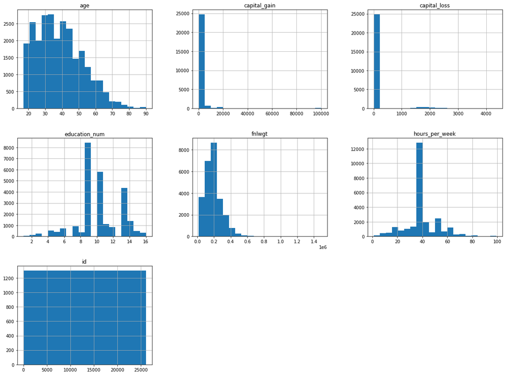

```python
# 수치형 데이터

train.hist(bins=20, figsize=(20,15))   # bins : 막대 그래프 개수. default==10   # y축 : 개수.
plt.show()
```

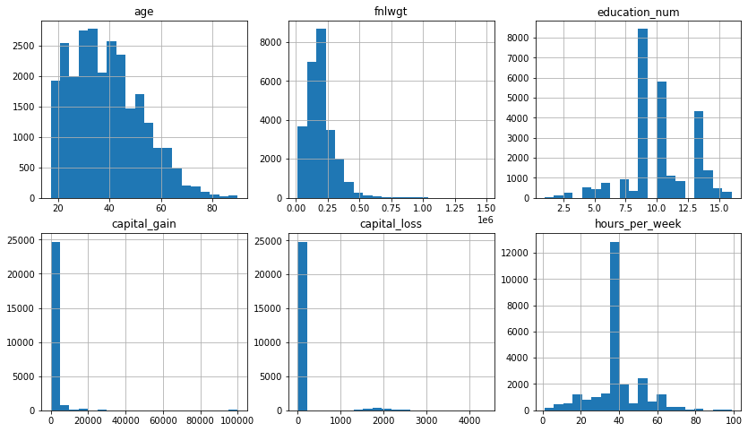

```python
# id feature 를 제외한 수치형 데이터

features = ['age', "fnlwgt", "education_num", "capital_gain", "capital_loss", "hours_per_week"]
i = 1

plt.figure(figsize=(14, 8))

for feature in features:
    plt.subplot(2, 3, i)
    train[feature].hist(bins=20)   #plt.hist(train[feature], bins=20) 와 같음.
    plt.title(feature)
    i += 1
```

### 파이 그래프 pie()

```python
### 범주형 데이터의 unique 한 범주 개수
print("범주형 데이터별 unique한 데이터 개수 :")
for col1 in train.columns:
    if train[col1].dtype == "object":
        categories = train[col1].unique()
        print(f"[{col1}] ({len(categories)})", end=" / ")

### 수치형 데이터의 unique 한 범주 개수
print("\n\n수치형 데이터별 unique한 데이터 개수 :")
for col2 in train.columns:
    if train[col2].dtype != "object":
        categories = train[col2].unique()
        print(f"[{col2}] ({len(categories)})", end=" / ")

### 범주형 수치형 관계없이 모든 데이터의 unique 한 범주 개수
print("\n\n범주형 및 수치형 데이터별 unique한 데이터 개수 :")
for col3 in train.columns:
    categories = train[col3].unique()
    print(f"[{col3}] ({len(categories)})", end=" / ")
```

```
범주형 데이터별 unique한 데이터 개수 :
[workclass] (9) / [education] (16) / [marital_status] (7) / [occupation] (15) / [relationship] (6) / [race] (5) / [sex] (2) / [native_country] (41) / [income] (2) /

수치형 데이터별 unique한 데이터 개수 :
[id] (26049) / [age] (73) / [fnlwgt] (18422) / [education_num] (16) / [capital_gain] (119) / [capital_loss] (90) / [hours_per_week] (93) /

범주형 및 수치형 데이터별 unique한 데이터 개수 :
[id] (26049) / [age] (73) / [workclass] (9) / [fnlwgt] (18422) / [education] (16) / [education_num] (16) / [marital_status] (7) / [occupation] (15) / [relationship] (6) / [race] (5) / [sex] (2) / [capital_gain] (119) / [capital_loss] (90) / [hours_per_week] (93) / [native_country] (41) / [income] (2…
```

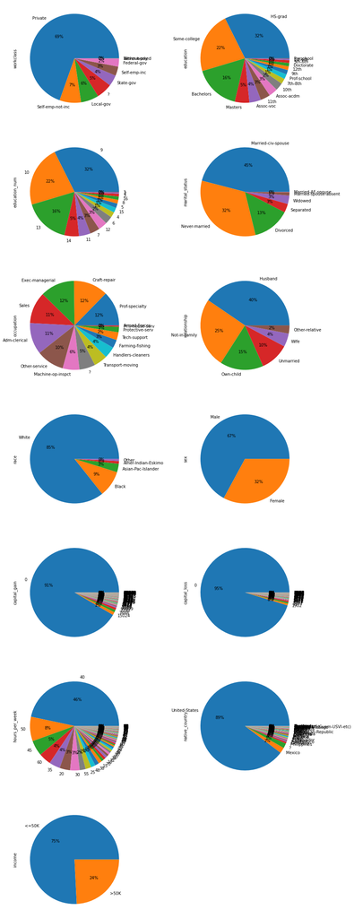

```python
all_col = ['workclass', 'education', 'education_num',
           'marital_status', 'occupation', 'relationship', 'race', 'sex',
           'capital_gain', 'capital_loss', 'hours_per_week', 'native_country',
           'income']
i=1

plt.figure(figsize=(14, 42))

for col in all_col:
    plt.subplot(7, 2, i)
    train[col].value_counts().plot.pie(autopct="%d%%") # value_counts() : 중복을 제외한 unique 한 데이터 개수.
                                                       # autopct : 표시할 자릿수. 0.1f 이면 소수점 첫재자리까지.
    i+=1
```

```python
train.describe()
```

|  | id | age | fnlwgt | education_num | capital_gain | capital_loss | hours_per_week |
| --- | --- | --- | --- | --- | --- | --- | --- |
| count | 26049.000000 | 26049.000000 | 2.604900e+04 | 26049.000000 | 26049.00000 | 26049.000000 | 26049.000000 |
| mean | 13024.000000 | 38.569235 | 1.903045e+05 | 10.088372 | 1087.68970 | 87.732734 | 40.443126 |
| std | 7519.842917 | 13.671489 | 1.059663e+05 | 2.567610 | 7388.85469 | 403.230205 | 12.361850 |
| min | 0.000000 | 17.000000 | 1.376900e+04 | 1.000000 | 0.00000 | 0.000000 | 1.000000 |
| 25% | 6512.000000 | 28.000000 | 1.181080e+05 | 9.000000 | 0.00000 | 0.000000 | 40.000000 |
| 50% | 13024.000000 | 37.000000 | 1.788660e+05 | 10.000000 | 0.00000 | 0.000000 | 40.000000 |
| 75% | 19536.000000 | 48.000000 | 2.377350e+05 | 12.000000 | 0.00000 | 0.000000 | 45.000000 |
| max | 26048.000000 | 90.000000 | 1.484705e+06 | 16.000000 | 99999.00000 | 4356.000000 | 99.000000 |

# [ Seaborn ]

```python
import seaborn as sns

print(sns.__version__)
```

```
0.10.1
```

### 막대그래프 1 (countplot)

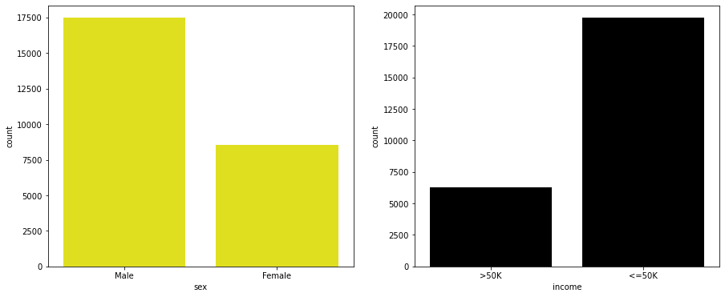

```python
### 성별, 연봉

fig, axes = plt.subplots(1, 2, figsize=(15, 6), sharey=False)

sns.countplot(x='sex', data=train, ax=axes[0], color="yellow")
sns.countplot(x='income', data=train, ax=axes[1], color="black")

plt.show()
```

< 그래프 해석 >

- 남자 : 여자 = 2 : 1
- 연봉 5만 불 초과 : 연봉 5만 불 이하 = 1 : 3

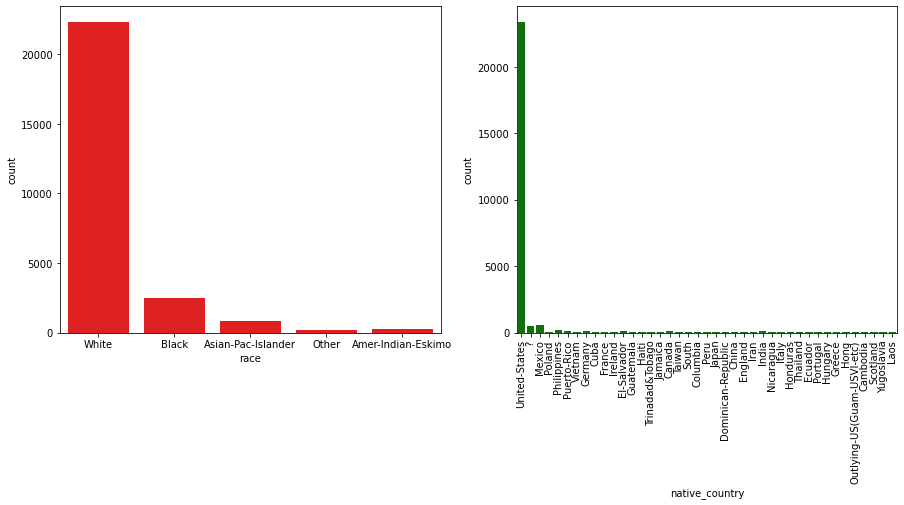

```python
### 인종, 국적

fig, axes = plt.subplots(1, 2, figsize=(15, 6), sharey=False)

sns.countplot(x='race', data=train, ax=axes[0], color="red")
sns.countplot(x='native_country', data=train, ax=axes[1], color="green")

plt.setp(axes[1].xaxis.get_majorticklabels(), rotation=90)

plt.show()
```

< 그래프 해석 >

- 인종의 경우 대부분이 백인(White)이다.
- 국적의 경우 대부분이 미국(Unite States)이다.

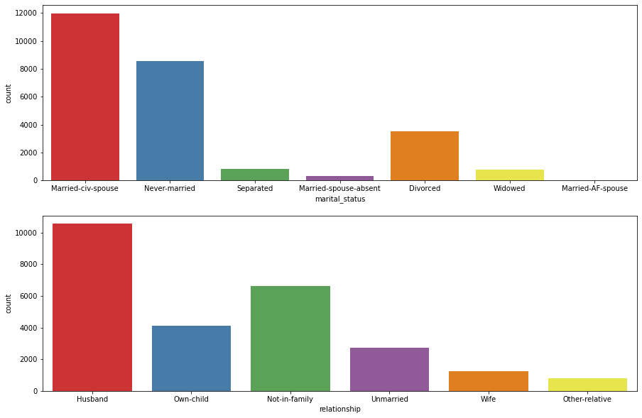

```python
### 결혼 상태, 가족 관계

plt.figure(figsize=(15, 10))

plt.subplot(2, 1, 1)
sns.countplot(x="marital_status", data=train, palette="Set1")

plt.subplot(2, 1, 2)
sns.countplot(x="relationship", data=train, palette="Set1")

plt.show()
```

< 그래프 해석 >

- 결혼 상태는 Married-civ-spouse이 가장 많고 Married-AF-spouse가 가장 적다.
- 가족 관계는 Husband가 있는 사람이 가장 많고 Other-relative가 있는 사람이 가장 적다.

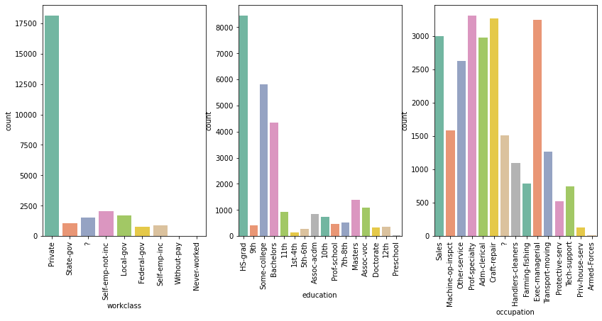

```python
### 고용 형태, 교육 수준, 업종

fig, axes = plt.subplots(1, 3, figsize=(14, 6), sharey=False)

sns.countplot(x='workclass', data=train, ax=axes[0], palette="Set2")
sns.countplot(x='education', data=train, ax=axes[1], palette="Set2")
sns.countplot(x='occupation', data=train, ax=axes[2], palette="Set2")

plt.setp(axes[0].xaxis.get_majorticklabels(), rotation=90)
plt.setp(axes[1].xaxis.get_majorticklabels(), rotation=90)
plt.setp(axes[2].xaxis.get_majorticklabels(), rotation=90)

plt.show()
```

< 그래프 해석 >

- 고용 형태는 대부분이 private이다.
- 교육 수준은 HS-grad가 가장 많고, Some-college, Bachelors 순으로 많다.
- 업종은 Prof-specialty, Craft-repair, Exec-managerial가 가장 많고, Sales, Adm-clearical가 뒤를 잇는다.

### 막대그래프 2 (barplot)

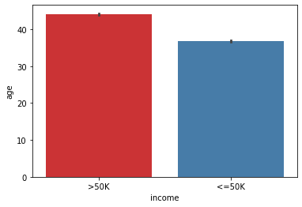

```python
### 연령, 연봉

sns.barplot(x="income", y="age", data=train, palette="Set1")
```

< 그래프 해석 >

- 연봉이 5만 불 초과인 사람들의 평균 연령이 5만 불 이하인 사람들의 평균 연령보다 더 높다.

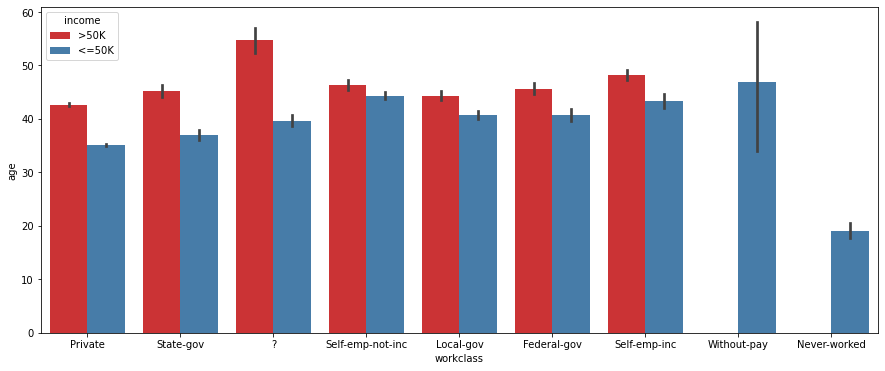

```python
### 연령, 고용 형태, 연봉

plt.figure(figsize=(15, 6))
sns.barplot(x="workclass", y="age", hue="income", data=train, palette="Set1")
plt.show()
```

< 그래프 해석 >

- 모든 고용 형태에서 연봉이 5만 불 초과인 사람들의 평균 연령이 5만 불 이하인 사람들의 평균 연령보다 더 높다.
- 단, 고용 형태가 Without-pay와 Never-worked인 경우 연봉이 5만 불 초과인 경우는 없다.

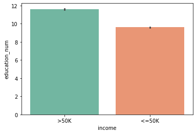

```python
### 교육 수준 수치, 연봉

sns.barplot(x="income", y="education_num", data=train, palette="Set2")
```

< 그래프 해석 >

- 연봉이 5만 불 초과인 사람들의 평균 교육 수준 수치가 5만 불 이하인 사람들의 평균 교육 수준 수치보다 더 높다.

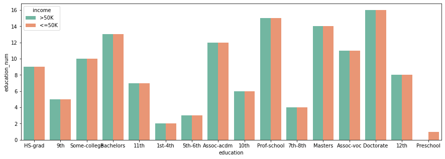

```python
### 교육 수준 수치, 교육 수준, 연봉

plt.figure(figsize=(15, 5))
sns.barplot(x="education", y="education_num", hue="income", data=train, palette="Set2")
plt.show()
```

< 그래프 해석 >

- 모든 교육 수준에서 연봉이 5만 불 초과인 사람들과 5만 불 이하인 사람들의 평균 교육 수준 수치는 같다.
- 단, 교육 수준이 (최종 학력) 유치원 졸업인 경우(Preschool) 연봉이 5만 불 초과인 경우는 없다.
- 두 집단 모두 박사(Doctorate) 학위를 취득한 사람들의 교육 수준 수치가 가장 높다.

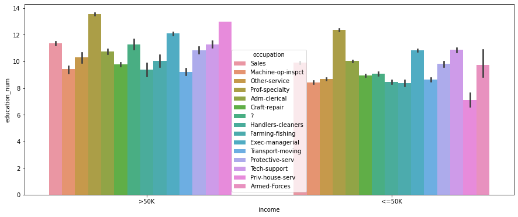

```python
### 교육 수준 수치, 업종, 연봉

plt.figure(figsize=(15, 6))
sns.barplot(x="income", y="education_num", hue="occupation", data=train)
plt.show()
```

< 그래프 해석 >

- 연봉이 5만 불 초과인 경우
  - 평균적으로 Prof-specialty, Priv-house-serv, Exec-managerial 순으로 교육 수준 수치가 높다.
  - 평균적으로 Transport-moving, Handlers-cleaners, Machine-op-inspct 순으로 교육 수준 수치가 낮다.
- 연봉이 5만 불 미만인 경우
  - 평균적으로 Prof-specialty, Tech-support, Exec-managerial 순으로 교육 수준 수치가 높다.
  - 평균적으로 Priv-house-serv, Farming-fishing, Machine-op-inspct 순으로 교육 수준 수치가 낮다.

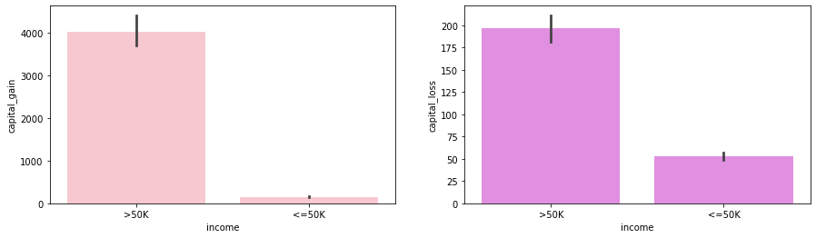

```python
### 양도 소득, 손실, 연봉

plt.figure(figsize=(15, 4))

plt.subplot(1, 2, 1)
sns.barplot(x="income", y="capital_gain", data=train, color="pink")

plt.subplot(1, 2, 2)
sns.barplot(x="income", y="capital_loss", data=train, color="violet")
```

< 그래프 해석 >

- 양도 소득과 양도 손실 모두 연봉이 5만 불 초과인 경우가 5만 불 미만인 경우보다 더 크다.
- 양도 소득의 경우
  - 연봉이 5만 불 초과인 사람들은 평균 4000불인 반면
  - 연봉이 5만 불 이하인 사람들은 평균 1000불의 반도 채 되지 않는다.
  - 즉 두 집단간의 이득을 본 차이가 크다.
- 양도 손실의 경우
  - 연봉이 5만 불 초과인 사람들은 평균 200불인 반면
  - 연봉이 5만 불 이하인 사람들은 평균 50불이다.
  - 즉 두 집단간의 손해를 본 차이가 양도 소득에 비해 크지 않다.

### 박스플롯 (boxplot)

boxplot 보충

- 이상값(outlier)(다이아몬드 모양) : 최솟값과 최댓값을 넘어가는 위치에 있는 값.
- 최댓값(maximum) : Q3+1.5*IQR (IQR=Q3-Q1. 즉 사분위간 범위)
- 3사분위 수(Q3)(upper quartile) : 오름차순 정렬 시 75% 위치의 값.
- 2사분위 수(Q2)(median) : 오름차순 정렬 시 50% 위치의 값. 즉 중앙값.
- 1사분위 수(Q1)(lower quartile) : 오름차순 정렬 시 25% 위치의 값.
- 최솟값(minimun) : Q1-1.5*IQR

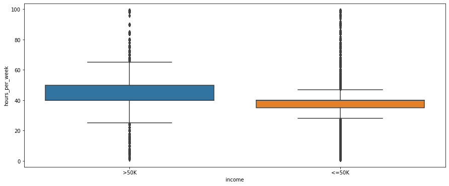

```python
# 주당 근무 시간별 연봉

plt.figure(figsize=(15, 6))
sns.boxplot(x="income", y="hours_per_week", data=train)
plt.show()
```

< 그래프 해석 >

- 평균적으로 연봉이 5만 불 초과인 사람들이 5만 불 이하인 사람들보다 주당 근무 시간이 더 길다.
- 연봉이 5만 불 초과인 사람들의 1사분위(25%)가 5만 불 이하인 사람들의 3사분위(75%)와 비슷하다. (약 40시간)

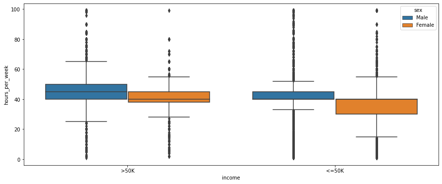

```python
# 성별 및 주당 근무 시간별 연봉

plt.figure(figsize=(15, 6))
sns.boxplot(x="income", y="hours_per_week", hue="sex", data=train)
plt.show()
```

< 그래프 해석 >

- 연봉이 5만 불 초과인 경우와 5만 불 이하인 경우 모두 평균적으로 남자가 여자보다 주당 근무 시간이 더 길다.
- 연봉이 5만 불 초과인 경우 남자의 2사분위(50%)가 여자의 3사분위(75%)와 비슷하다.
- 연봉이 5만 불 이하인 경우 남자의 1사분위(25%)가 여자의 3사분위(75%)와 비슷하다.

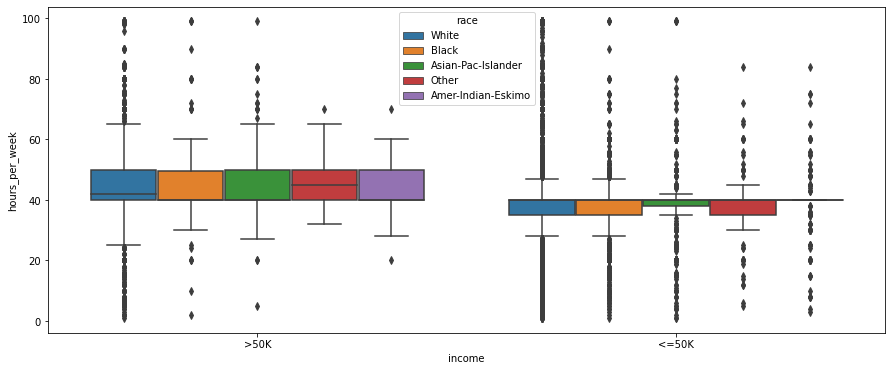

```python
# 인종 및 주당 근무 시간별 연봉

plt.figure(figsize=(15, 6))
sns.boxplot(x="income", y="hours_per_week", hue="race", data=train)
plt.show()
```

< 그래프 해석 >

- 연봉이 5만 불 초과인 경우
  - 모든 인종의 주당 근무 시간 1사분위(25%)와 3사분위(75%)가 비슷하다.
  - 하지만 White, Black, Asian-Pac_Islander의 경우 주당 근무 시간이 0~ 100시간까지 고르게 분포되어있는 반면
  - Others, Amer-Indian_Eskimo는 주당 근무 시간이 20~70 시간 사이에 분포해 있다.
- 연봉이 5만 불 이하인 경우
  - Amer-Indian_Eskimo를 제외하고 모든 인종의 주당 근무 시간 3사분위(75%)가 비슷하다.
  - 하지만 White, Black, Asian-Pac_Islander의 경우 주당 근무 시간이 0~ 100시간까지 고르게 분포되어있는 반면
  - Others, Amer-Indian_Eskimo는 주당 근무 시간이 5~85 시간 사이에 분포해 있다.